# Inferencia paramétrica

$X_1,...,X_n \sim p(x; \theta)$. Queremos estimar $\theta=(\theta_1,...,\theta_k)$ . Un estimador
$$\hat{\theta} = w(X_1,...,X_n)$$
es una función de los datos.

El método más común para estimar parámetros es el **método de máxima verosimilitud**. Sea $X_1,...,X_n$ independientes e idénticamente distribuidas con función de densidad de probabilidad $p(x;\theta)$ entonces:

La **función de verosimilitud** se define como:
$$\mathcal{L}(\theta) = \prod_{í=1}^n p(x_i;\theta).$$
y la **log-verosimilitud** se define como
$$\mathcal{l}(\theta)=\log \mathcal{L}(\theta)=\sum_{i=1}^n \log p(x_i; \theta)$$

La función de verosimilitud no es mas que la densidad conjunta de los datos, con la diferencia de que la **tratamos como función del parámetro** $\theta$. Por tanto $\mathcal{L}:\Theta \to [0, \infty)$, en general $\mathcal{L}(\theta)$ no integra uno respecto a $\theta$.

El **estimador de máxima verosimilitud** es el valor de $\theta$ que maximiza $\mathcal{L}(\theta)$.

El máximo de $\mathcal{l}(\theta)$ se alcanza en el mismo lugar que el máximo de $\mathcal{L}(\theta)$, por lo que maximizar la log-verosimilitud es equivalente a maximizar la verosimilitud.

**Ejemplo: Bernoulli**. Supongamos $X_1,...X_n \sim Bernoulli(\theta)$. La función de densidad correspondiente es $p(x;\theta)=\theta^x(1-\theta)^{1-x}$, por lo que:

$$\mathcal{L}(p)=\prod_{i=1}^n p(x_i;\theta)=\prod_{i=1}^n \theta^{x_i}(1-\theta)^{1-x_i}=\theta^{\sum x_i}(1-\theta)^{n-\sum x_i}$$

denotemos $S=\sum x_i$, entonces
$$\mathcal{l}(\theta)=S \log \theta + (n-S) \log (1-\theta)$$
.

Si n=20 y S=12 tenemos la función:

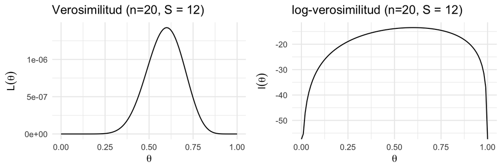

```r
# Verosimilitud X_1,...,X_n ~ Bernoulli(theta)
L_bernoulli <- function(n, S){
    function(theta){
        theta ^ S * (1 - theta) ^ (n - S)
    }
}
# log-verosimilitud
l_bernoulli <- function(n, S){
    function(theta){
        S * log(theta) + (n - S) * log(1 - theta)
    }
}
xy <- data.frame(x = 0:1, y = 0:1)
verosimilitud <- ggplot(xy, aes(x = x, y = y)) +
    stat_function(fun = L_bernoulli(n = 20, S = 12)) +
    xlab(expression(theta)) +
    ylab(expression(L(theta))) +
    ggtitle("Verosimilitud (n=20, S = 12)")

log_verosimilitud <- ggplot(xy, aes(x = x, y = y)) +
    stat_function(fun = l_bernoulli(n = 20, S = 12))+
    xlab(expression(theta)) +
    ylab(expression(l(theta))) +
    ggtitle("log-verosimilitud (n=20, S = 12)")

grid.arrange(verosimilitud, log_verosimilitud, nrow = 1)
```

En ocasiones podemos calcular el estimador de máxima verosimilitud analíticamente, esto es derivando respecto al vector de parámetros de interés, igualando a cero el sistema de ecuaciones resultante, y revisando la segunda derivada para asegurar que se encontró un máximo. En el ejemplo este proceso lleva a $\hat{\theta}=S/n$, y con $S=12, n = 20$ obtenemos $\hat{\theta}=0.6$

Es muy común recurrir a métodos numéricos (por ejemplo Newton Raphson, BHHH, DFP) en el caso de R podemos usar las funciones `optim` u `optimize`.

```r
optimize(L_bernoulli(n = 20, S = 12), interval = c(0, 1), maximum = TRUE)
```

```
#> $maximum
#> [1] 0.6
#>
#> $objective
#> [1] 1.43e-06
```

```r
optimize(l_bernoulli(n = 20, S = 12), interval = c(0, 1), maximum = TRUE)
```

```
#> $maximum
#> [1] 0.6
#>
#> $objective
#> [1] -13.5
```

Sean $X_1,...X_n \sim N(\mu, \sigma^2)$.

- Calcula el estimador de máxima verosimilitud para $\theta = (\mu, \sigma^2)$. Supongamos que observamos una muestra de tamaño 100 tal que: $\sum X_i = 40$ y $\sum X_i^2 = 20$.
- Calcula $\hat{\theta}$ usando el método de máxima verosimilitud.
- ¿Cómo graficarías la verosimilitud o log-verosimilitud?

### Propiedades de los estimadores de máxima verosimilitud

Bajo ciertas condiciones del modelo, el estimador de máxima verosimilitud $\hat{\theta}$ tiene propiedades deseables, las principales son:

1. **Consistencia**: $\hat{\theta} \xrightarrow{P} \theta$ (converge en probabilidad), donde $\theta$ es el verdadero valor del parámetro.
2. **Equivariante**: Si $\hat{\theta}$ es el estimador de máxima verosimilitud de $\theta$, entonces $g(\hat{\theta})$ es el estimador de máxima verosimilitud de $g(\theta)$.

Supongamos $g$ invertible, entonces $\hat{\theta} = g^{-1}(\hat{\eta})$. Para cualquier $\eta$,
$$\mathcal{L}(\eta)=\prod_{i=1}^n p(x_i;g^{-1}(\eta)) = \prod_{i=1}^n p(x_i;\theta)=\mathcal{L}(\theta)$$
Por lo tanto, para cualquier $\eta$,
$$\mathcal{L}(\eta)=\mathcal{L}(\theta) \leq \mathcal{L}(\hat{\theta})=\mathcal{L}(\hat{\eta})$$
y concluimos que $\hat{\eta}=g(\hat{\theta})$ maximiza $\mathcal{L}(\eta)$.

Ejemplo: Binomial. El estimador de máxima verosimilitud es $\hat{p}=\bar{X}$. Si $\eta=log(p/(1-p)$, entonces el estimador de máxima verosimilitud es $\hat{\eta}=log(\hat{p}/(1-\hat{p}))$

3. **Asintóticamente normal**: $\hat{\theta} \leadsto N(\theta, I(\theta)^{-1})$, veremos a que nos referimos con $ I()^{-1}$ en la siguiente sección.

```r
sim_sigma_hat <- function(n = 50, mu_sim = 0, sigma_sim = 1){
    x <- rnorm(n, mu_sim, sigma_sim)
    sigma_hat <- sqrt(sum((x - mean(x)) ^ 2) / n)
}

sigma_hats <- rerun(1000, sim_sigma_hat(n = 50, mu_sim = 10, sigma_sim = 5)) %>%
    flatten_dbl()

# aprox normal con media theta y error estándar
mean(sigma_hats)
```

```
#> [1] 4.93
```

```r
sd(sigma_hats)
```

```
#> [1] 0.51
```

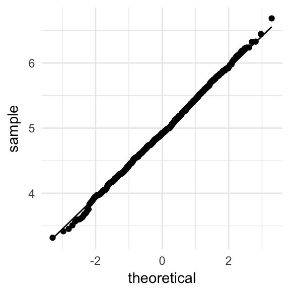

```r
ggplot(data_frame(sigma_hats), aes(sample = sigma_hats)) +
    stat_qq() +
    stat_qq_line()
```

4. **Asintóticamente eficiente**: A grandes razgos, esto quiere decir que del conjunto de estimadores con comportamiento estable, el estimador de máxima verosimilitud tiene la menor varianza al menos para muestras grandes (alcanza la cota de Cramer-Rao).

Ahora que tenemos estimadores de maxima verosimilitud resta calcular errores estándar.